# Trends in growth, rwp and photosyn

**Objective**: To see if CO2 mesophyll resistance (rwp) is realted to total growth traits.

**Data limiations**: photosynthesis realted traits are from greenhouse and growth characteristics are from field.

**Growth data files**: Corv_2012_Growth_rep1.csv, Corv_2012_Growth_rep2.csv, Corv_2012_Growth_rep3.csv, GWAS_Clatskanis_july_2013_Height_Diameter.csv

**Photosyn data files**: datainput_2_27_2015.csv

**Local Git directory**: setwd(“~/GitHub/poplar_GWAS_photosyn”)

**Field Traits**  
HBS3 Height to the bud scar of year 3 (2011 height)  
HBS2 Height to the bud scar of year 2 (2010 height)  
HHB height to the highest branch columns F-M are mostly repeated, but with 4 noted trees. What are they for? D20 diameter 20cm  
D50 diameter 50cm - for stem taper  
BA Branch angle  
SB sylleptic branches from last year’s growth (2011)  
LENT # lenticels in 5cm along trunk  
Tephrina 0-4: 0=zero; 1=1-25%; 2=26-50%; 3=51-75%; 4=76-100%  
Venturia 0-4: 0=zero; 1=1-25%; 2=26-50%; 3=51-75%; 4=76-100%

**Data manipulation and Gm calculation** Note: can only caluclate Gm for samples that have rwp > 0.

**Relationship with Clatskanis Height Diameter data using replilcate 1**

```
##
##  Pearson's product-moment correlation
##
## data:  rwp and D50
## t = 2.0565, df = 319, p-value = 0.04055
## alternative hypothesis: true correlation is not equal to 0
## 95 percent confidence interval:
##  0.004978977 0.221086030
## sample estimates:
##       cor
## 0.1143855
```

```
##
##  Pearson's product-moment correlation
##
## data:  rwp and D20
## t = -0.471, df = 319, p-value = 0.638
## alternative hypothesis: true correlation is not equal to 0
## 95 percent confidence interval:
##  -0.13543889  0.08334856
## sample estimates:
##         cor
## -0.02636084
```

**Relationship with Clatskanis Height Diameter data using replilcate 2**

```
##
##  Pearson's product-moment correlation
##
## data:  rwp and D50
## t = -0.1162, df = 314, p-value = 0.9075
## alternative hypothesis: true correlation is not equal to 0
## 95 percent confidence interval:
##  -0.1168077  0.1038484
## sample estimates:
##          cor
## -0.006559484
```

```
##
##  Pearson's product-moment correlation
##
## data:  rwp and D20
## t = 0.3181, df = 314, p-value = 0.7506
## alternative hypothesis: true correlation is not equal to 0
## 95 percent confidence interval:
##  -0.09256919  0.12802602
## sample estimates:
##        cor
## 0.01794682
```

**correlegrams** **Clatskanis Height Diameter data using replilcate 2**

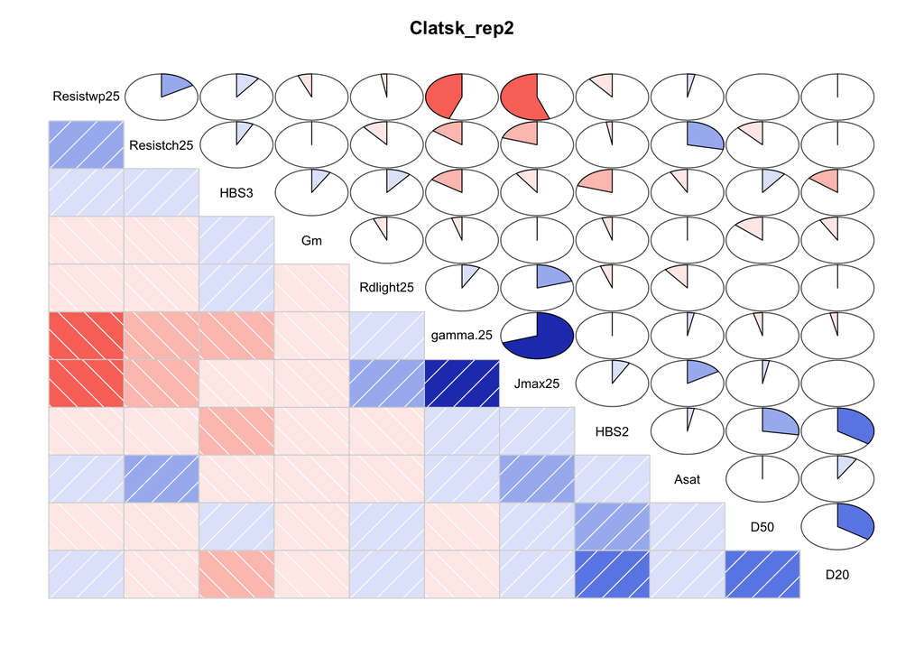

```r
library(corrgram)

#convert some columns to numeric

datClatHt_2_join<-datClatHt_2_join %>% select(-Duplicate, -id, -Block)
datClatHt_2_join[, c(8:11)] <- sapply(datClatHt_2_join[, c(8:11)], as.numeric)

corrgram(datClatHt_2_join, order=TRUE, lower.panel=panel.shade,
  upper.panel=panel.pie, text.panel=panel.txt,
  main="Clatsk_rep2")
```

**correlegrams** **Clatskanis Height Diameter data using replilcate 1**

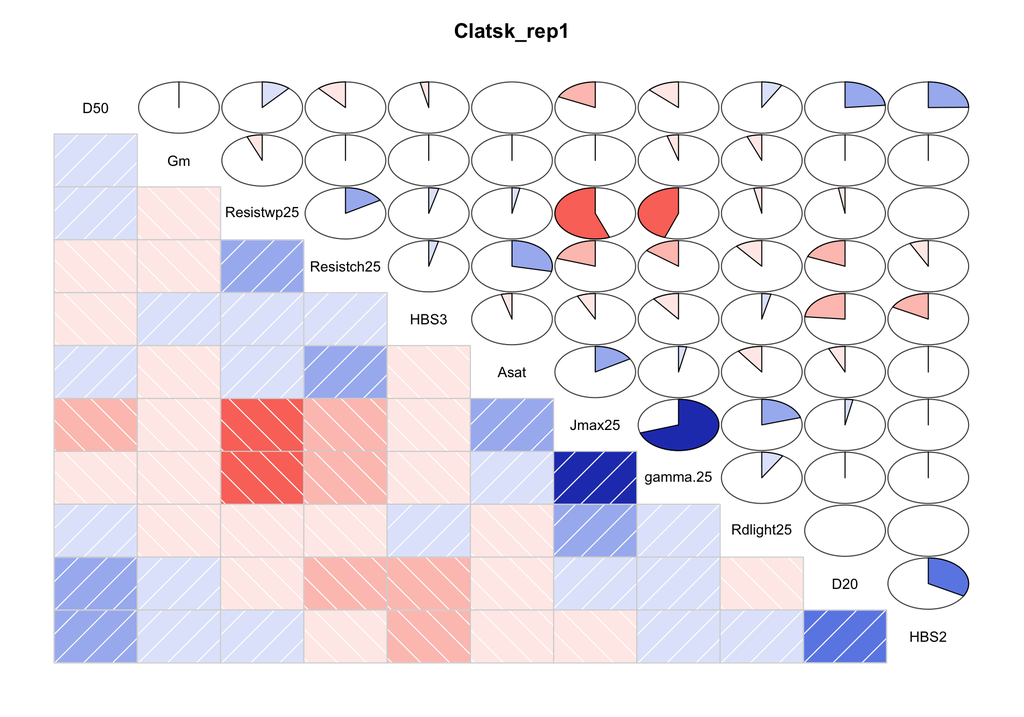

```r
library(corrgram)

#convert some columns to numeric

datClatHt_1_join<-datClatHt_1_join %>% select(-Duplicate, -id, -Block)
datClatHt_1_join[, c(8:11)] <- sapply(datClatHt_1_join[, c(8:11)], as.numeric)

corrgram(datClatHt_1_join, order=TRUE, lower.panel=panel.shade,
  upper.panel=panel.pie, text.panel=panel.txt,
  main="Clatsk_rep1")
```

**correlegrams** **Corvalis replilcate 1**

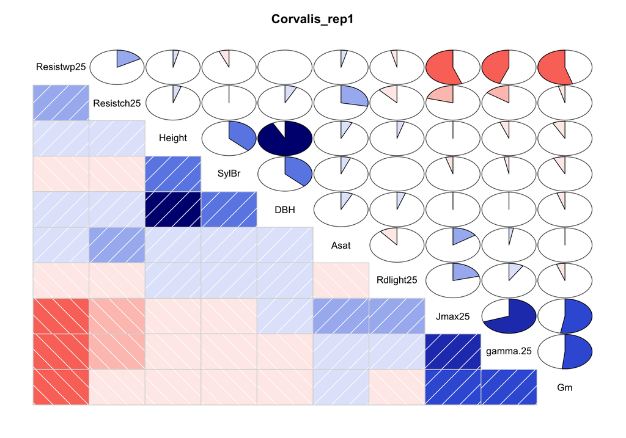

```r
datCor_1<-datCor_1 %>% select(id=Geno, Height=Corv_R1_Height_2012, DBH=Corv_R1_DBH_2012, SylBr=SylBr_2012)
datCor_1_join<-inner_join(dat2, datCor_1, by = "id")
datCor_1_join<-datCor_1_join %>% select(-Duplicate)
datCor_1_join[, c(9:11)] <- sapply(datCor_1_join[, c(9:11)], as.numeric)

corrgram(datCor_1_join, order=TRUE, lower.panel=panel.shade,
  upper.panel=panel.pie, text.panel=panel.txt,
  main="Corvalis_rep1")
```

**correlegrams** **Corvalis replilcate 2**

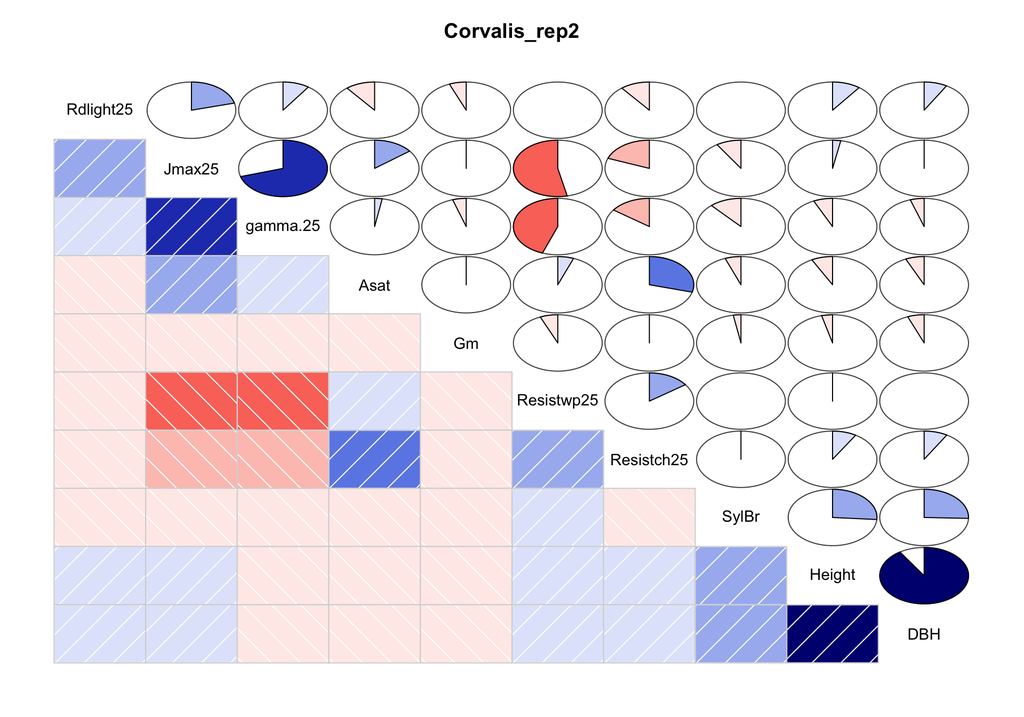

```r
datCor_2<-datCor_2 %>% select(id=Geno, Height=Corv_R2_Height_2012, DBH=Corv_R3_DBH_2012, SylBr=SylBr_2012)
datCor_2_join<-inner_join(dat2, datCor_2, by = "id")
datCor_2_join<-datCor_2_join %>% select(-Duplicate)
datCor_2_join[, c(9:11)] <- sapply(datCor_2_join[, c(9:11)], as.numeric)

corrgram(datCor_2_join, order=TRUE, lower.panel=panel.shade,
  upper.panel=panel.pie, text.panel=panel.txt,
  main="Corvalis_rep2")
```

**correlegrams** **Corvalis replilcate 3**

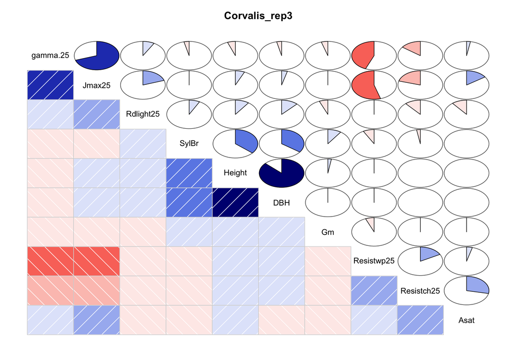

```r
datCor_3<-datCor_3 %>% select(id=Geno, Height=Corv_R3_Height_2012, DBH=Corv_R3_DBH_2012, SylBr=SylBr_2012)
datCor_3_join<-inner_join(dat2, datCor_3, by = "id")
datCor_3_join<-datCor_3_join %>% select(-Duplicate)
datCor_3_join[, c(9:11)] <- sapply(datCor_3_join[, c(9:11)], as.numeric)

corrgram(datCor_3_join, order=TRUE, lower.panel=panel.shade,
  upper.panel=panel.pie, text.panel=panel.txt,
  main="Corvalis_rep3")
```